# Processing of SP3 binding data in different conditions

### Description

- MGF files were generated using RawQuant.
- The data were searched using SearchCLI and PeptideShakerCLI.
- Raw files were parsed for quantification data with RawQuant.

### Analysis

First call the libraries that are required.

```r
#library(Biostrings)
library(Rmisc)
library(dplyr)
library(ggplot2)
library(RColorBrewer)
library(cowplot)
library(tidyr)
#library(reshape)
library(data.table)
library(UpSetR)
#library(stringr)
#library(Peptides)
```

First thing we want to do is compile the identifications data into a usable object for plotting. This involves taking the output from PeptideShaker and combining it with the RawQuant data. This is carried out using the code below.

## Incubation time data set

First I want to look at the incubation time data. Locate the input files for identifications and quantification.

```r
id_files = list.files('/projects/ptx_analysis/chughes/projects-current/sp3-follow-up/binding-testing/reports-output', pattern='.*Duration.*Default_PSM_Report.txt',full.names=TRUE) #psm files
quant_files = list.files('/projects/ptx_analysis/chughes/projects-current/sp3-follow-up/binding-testing/quant-output', pattern='.*Duration.*MS2ParseData.txt',full.names=TRUE) #ms2 files
```

Read in the identification data into a single data frame object.

```r
id_parsed = data.frame() #identification data storage object
#iterate over the identification files
for (i in 1:length(id_files)){
  psm_in = read.table(id_files[i],header=TRUE,sep='\t') #input file
  psm_f1 = psm_in %>%
    dplyr::select(Protein.s., Sequence, Spectrum.File, Spectrum.Title, m.z, Identification.Charge) %>% #select columns
    dplyr::mutate(Spectrum.Title, scan_num = sub(".*?spectrum (.*?)", "\\1", Spectrum.Title)) %>% #parse out the scan number
    dplyr::mutate(Identification.Charge, id_charge = gsub("[^0-9]", "", Identification.Charge)) %>% #parse out the charge
    dplyr::mutate(Spectrum.Title, fraction = sub(".*?100p_(.*?)_[0-9]_MGF\\.mgf", "\\1", Spectrum.File)) %>% #parse the fraction
    dplyr::mutate(Spectrum.Title, replicate = sub(".*?min_(.*?)_MGF\\.mgf", "\\1", Spectrum.File)) %>% #parse the replicate
    dplyr::select(Protein.s., Sequence, scan_num, m.z, id_charge, fraction, replicate) %>% #select new columns
    dplyr::mutate(Protein.s., first_accession = sapply(strsplit(as.character(Protein.s.),"\\,"), `[`, 1)) #parse the accession
  #adjust the column names
  colnames(psm_f1) = c('accession_groups','sequence','ScanNumber','id_precursor_mz','id_charge','fraction','replicate','accession')
  psm_f2 = dplyr::filter(psm_f1, !grepl('CONT_', accession_groups)) #remove the contaminant proteins
  id_parsed = rbind(id_parsed,psm_f2) #group the data with the previously processed set
}
```

Now we can process the rawquant data for the intensity values.

```r
quant_parsed = data.frame()
#iterate over the rawquant files
for (i in 1:length(quant_files)){
  quant_in = read.table(quant_files[i],header=TRUE,sep='\t') #input file
  quant_in$fraction = sub(".*?100p_(.*?)_[0-9]_MS2ParseData\\.txt", "\\1", quant_files[i]) #parse out the fraction
  quant_in$replicate = sub(".*?min_(.*?)_MS2ParseData\\.txt", "\\1", quant_files[i]) #parse out the replicate
  quant_parsed = rbind(quant_parsed, quant_in) #combine with the previous data
}
```

Now we can combine the two data sets together using a simple merge and save the data.

```r
id_quant = merge(id_parsed, quant_parsed, by=c('ScanNumber', 'fraction', 'replicate'))
saveRDS(id_quant, '/projects/ptx_analysis/chughes/projects-current/sp3-follow-up/binding-testing/Routput/ch_feb2018_SP3-binding-incubation-time_id-quant-all.rds') #save the data
```

Now that I have the compiled data set, I want to plot how well the identified peptides track across the different incubation times. I can do this using their intensities from rawquant.

```r
###first read in the data file I just prepared
psm_set = readRDS('/projects/ptx_analysis/chughes/projects-current/sp3-follow-up/binding-testing/Routput/ch_feb2018_SP3-binding-incubation-time_id-quant-all.rds') #read processed data
```

Collapse redundant psm’s in the data.

```r
psm_agg <- setDT(psm_set)[, lapply(.SD,mean,na.rm=TRUE),by=.(sequence,fraction,replicate),.SDcols=c('PrecursorMaxIntensity')] #collapse by sequence and replicate
setDF(psm_agg) # convert back to dataframe
dim(psm_agg) #58323 rows are remaining
```

```
[1] 58323     4
```

I am only interested in peptides that were identified in all 6 samples for this specific plot.

```r
peptide_set = names(which(table(psm_agg$sequence) == 6)) #extract the peptides found in all 6 samples, this keeps 4397 peptides
peptide_subset = psm_agg[psm_agg$sequence %in% peptide_set,] #filter the data matrix to only keep peptides found in all 6 samples
dim(peptide_subset) #this should be 4397 * 6 rows in length, and it is!
```

```
[1] 26382     4
```

Now plot the data in a boxplot.

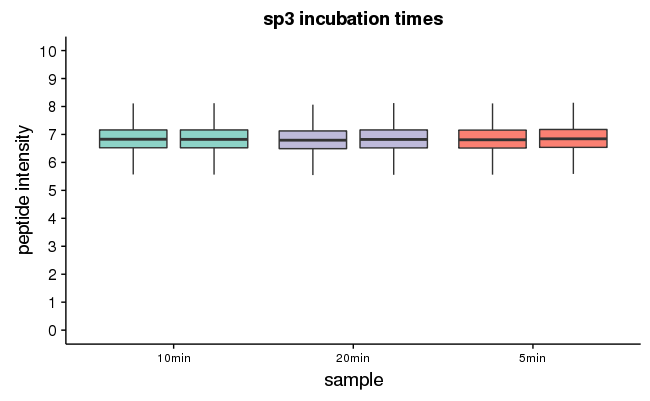

```r
incubation_plot = ggplot(peptide_subset, aes(fraction, log10(PrecursorMaxIntensity),group=interaction(replicate,fraction))) +
    #geom_point(aes(fill=fraction),position=position_jitterdodge(dodge.width=0.9),colour='grey60',alpha=0.1) +
    geom_boxplot(aes(fill=fraction), position=position_dodge(width=0.9),outlier.colour=NA) +
    labs(x = "sample", y = 'peptide intensity', title = 'sp3 incubation times') +
    theme(axis.text.x = element_text(size = 9)) +
    #scale_y_continuous(limits=c(0,1.5e9)) +
    theme(legend.position="none") +
    scale_fill_manual(values=brewer.pal(6,"Set3")[c(1,3:4)]) +
    scale_y_continuous(limits = c(0,10), breaks = seq(0,10,1))
incubation_plot #call the plot
save_plot('/projects/ptx_analysis/chughes/projects-current/sp3-follow-up/binding-testing/Routput/ch_feb2018_SP3-binding-incubation-time_peptide-boxplot.pdf',incubation_plot)
```

This looks good…but it doesn’t tell me anything about recovery of identical peptides across the incubation times. For this we could use a correlation. Calculate and plot the correlation in intensities between a pair of replicate samples.

```r
peptide_wide = spread(peptide_subset, fraction, PrecursorMaxIntensity) #convert to wide format
cor(peptide_wide[,3:5],method = 'pearson')
```

```
          10min     20min      5min
10min 1.0000000 0.9250320 0.9455061
20min 0.9250320 1.0000000 0.9230528
5min  0.9455061 0.9230528 1.0000000
```

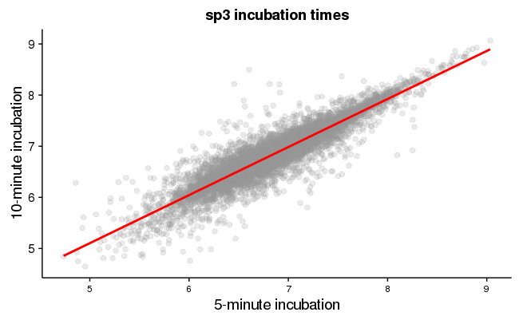

```r
#so the correlation is very nice here. Can state these values in the text, but make one plot as a display.
colnames(peptide_wide) = c('sequence','replicate','t10min','t20min','t5min')
incubation_corplot = ggplot(peptide_wide, aes(log10(t5min), log10(t10min))) +
    geom_point(colour='grey60',alpha=0.2,size=2) +
    geom_smooth(method='lm',color='red') +
    labs(x = "5-minute incubation", y = '10-minute incubation', title = 'sp3 incubation times') +
    theme(axis.text.x = element_text(size = 9)) +
    #scale_y_continuous(limits=c(0,1.5e9)) +
    theme(legend.position="none")
incubation_corplot #call the plot
save_plot('/projects/ptx_analysis/chughes/projects-current/sp3-follow-up/binding-testing/Routput/ch_feb2018_SP3-binding-incubation-time-5v10min_peptide-scatter.pdf',incubation_corplot)
```

```r
dim(peptide_wide) #26382 values present in this plot
```

```
[1] 8794    5
```

I am also interested to look at some identification metrics for these data.

```r
###first read in the data file I just prepared
psm_set = readRDS('/projects/ptx_analysis/chughes/projects-current/sp3-follow-up/binding-testing/Routput/ch_feb2018_SP3-binding-incubation-time_id-quant-all.rds') #read processed data
```

Collapse redundant psm’s in the data.

```r
psm_agg <- setDT(psm_set)[, lapply(.SD,mean,na.rm=TRUE),by=.(sequence,fraction,replicate),.SDcols=c('PrecursorMaxIntensity')] #collapse by sequence, fraction, and replicate
setDF(psm_agg) # convert back to dataframe
dim(psm_agg) #58323 rows are remaining
```

```
[1] 58323     4
```

```r
###what do the general peptide identification metrics look like
table(psm_agg$fraction, psm_agg$replicate)
```

```
            1     2
  10min  9822  9706
  20min  9262 10285
  5min   9359  9889
```

Make a plot of these data.

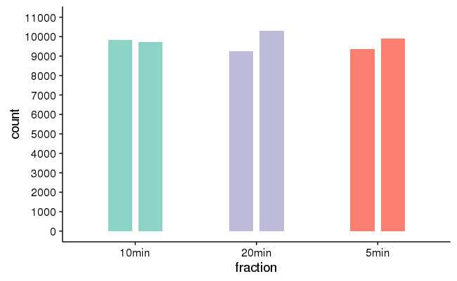

```r
#id_table = table(psm_agg$fraction, psm_agg$replicate)
###make the plot
id_plot = ggplot(psm_agg, aes(fraction, group=interaction(replicate,fraction))) +
  geom_bar(aes(fill=fraction), width=0.4, position = position_dodge(width=0.5)) +
  theme(legend.position="none") +
  scale_fill_manual(values=brewer.pal(6,"Set3")[c(1,3:4)]) +
  scale_y_continuous(limits = c(0,11000), breaks = seq(0,11000,1000))
id_plot #call the plot
save_plot('/projects/ptx_analysis/chughes/projects-current/sp3-follow-up/binding-testing/Routput/ch_feb2018_SP3-binding-incubation-time_peptide-barplot.pdf',id_plot)
```

Now look at the peptide overlap.

```r
psm_agg$number.of.hits = 1 #add a peptide counter
psm_agg$sample.set = paste(psm_agg$fraction,'_',psm_agg$replicate,sep="") #add a more specific sample description
peptide_wide = spread(psm_agg[,c(1,6,5)], sample.set, number.of.hits) #convert to wide format
peptide_wide[is.na(peptide_wide)] = 0 #change the NA values during the wide conversion to zeros for the UpSet plot
```

Make an upset ploto of the data.

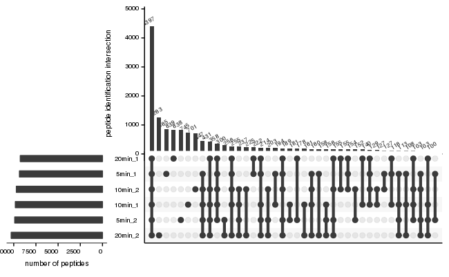

```r
#pdf('/projects/ptx_analysis/chughes/projects-current/sp3-follow-up/binding-testing/Routput/ch_feb2018_SP3-binding-incubation-time_identification-overlap-all.pdf')
#upset(peptide_wide, nsets = 8, number.angles = 30, point.size = 2.5, line.size = 1.5,
#    mainbar.y.label = "peptide identification intersection", sets.x.label = "number of peptides", order.by = "freq", mb.ratio = c(0.55, 0.45))
#dev.off()
all_sets_upset = upset(peptide_wide, nsets = 8, number.angles = 30, point.size = 2.5, line.size = 1.5,
    mainbar.y.label = "peptide identification intersection", sets.x.label = "number of peptides", order.by = "freq", mb.ratio = c(0.55, 0.45))
```

```r
psm_fraction_agg <- setDT(psm_set)[, lapply(.SD,mean,na.rm=TRUE),by=.(sequence,fraction),.SDcols=c('PrecursorMaxIntensity')] #collapse by fraction
setDF(psm_fraction_agg) # convert back to dataframe
psm_fraction_agg$number.of.hits = 1 #add a peptide counter
peptide_wide = spread(psm_fraction_agg[,c(1,2,4)], fraction, number.of.hits) #convert to wide format
peptide_wide[is.na(peptide_wide)] = 0 #change the NA values during the wide conversion to zeros for the UpSet plot
```

Make the plot of the data.

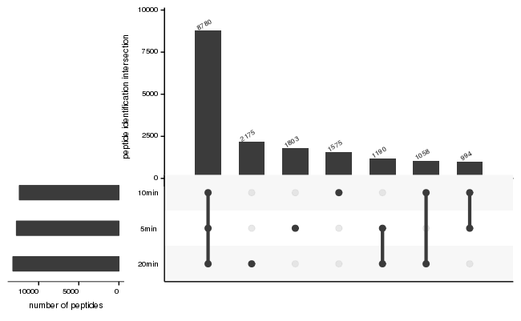

```r
#pdf('/projects/ptx_analysis/chughes/projects-current/sp3-follow-up/binding-testing/Routput/ch_feb2018_SP3-binding-incubation-time_identification-overlap-fractions.pdf')
#upset(peptide_wide, nsets = 4, number.angles = 30, point.size = 2.5, line.size = 1.5,
#    mainbar.y.label = "peptide identification intersection", sets.x.label = "number of peptides", order.by = "freq", mb.ratio = c(0.55, 0.45))
#dev.off()
fractions_upset = upset(peptide_wide, nsets = 4, number.angles = 30, point.size = 2.5, line.size = 1.5,
    mainbar.y.label = "peptide identification intersection", sets.x.label = "number of peptides", order.by = "freq", mb.ratio = c(0.55, 0.45))
```

Would also be interested to know the overlap between replicates, although I don’t think a plot is necessary here.

```r
psm_agg <- setDT(psm_set)[, lapply(.SD,mean,na.rm=TRUE),by=.(sequence,fraction,replicate),.SDcols=c('PrecursorMaxIntensity')] #collapse by sequence, fraction, and replicate
setDF(psm_agg) # convert back to dataframe
psm_agg_replicates = subset(psm_agg, fraction == '20min') #subset by the set of interest...just change this to see the others
psm_agg_replicates$number.of.hits = 1 #add a peptide counter
psm_agg_replicates$sample.set = paste(psm_agg_replicates$fraction,'_',psm_agg_replicates$replicate,sep="") #add a more specific sample description
peptide_wide = spread(psm_agg_replicates[,c(1,6,5)], sample.set, number.of.hits) #convert to wide format
peptide_wide[is.na(peptide_wide)] = 0 #change the NA values during the wide conversion to zeros for the UpSet plot
```

Make the plot of the data.

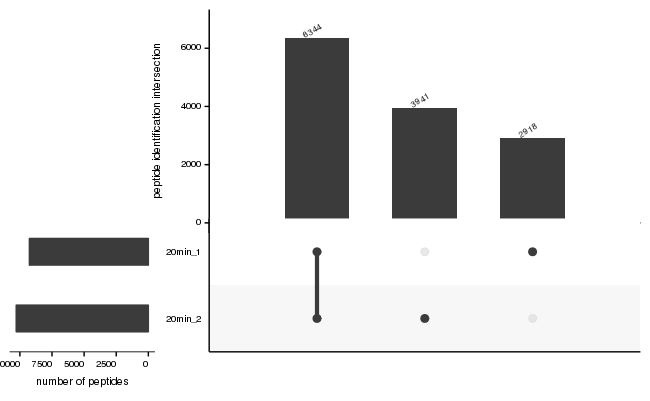

```r
#pdf('/projects/ptx_analysis/chughes/projects-current/sp3-follow-up/binding-testing/Routput/ch_feb2018_SP3-binding-incubation-time_20min_identification-overlap.pdf')
#upset(peptide_wide, nsets = 2, number.angles = 30, point.size = 2.5, line.size = 1.5,
#    mainbar.y.label = "peptide identification intersection", sets.x.label = "number of peptides", order.by = "freq", mb.ratio = c(0.55, 0.45))
#dev.off()
replicates_upset = upset(peptide_wide, nsets = 2, number.angles = 30, point.size = 2.5, line.size = 1.5,
    mainbar.y.label = "peptide identification intersection", sets.x.label = "number of peptides", order.by = "freq", mb.ratio = c(0.55, 0.45))
```

So the overlap here is around 65% based on peptide identifications. I am also interested in seeing the same data, but for proteins

```r
###first read in the data file I just prepared
psm_set = readRDS('/projects/ptx_analysis/chughes/projects-current/sp3-follow-up/binding-testing/Routput/ch_feb2018_SP3-binding-incubation-time_id-quant-all.rds') #read processed data
```

Collapse redundant peptides in the data.

```r
pep_agg <- setDT(psm_set)[, lapply(.SD,mean,na.rm=TRUE),by=.(accession,fraction,replicate),.SDcols=c('PrecursorMaxIntensity')] #collapse by accession, fraction, and replicate
setDF(pep_agg) # convert back to dataframe
dim(pep_agg) #20879 rows are remaining
```

```
[1] 15553     4
```

```r
###what do the general protein identification metrics look like
table(pep_agg$fraction, pep_agg$replicate)
```

```
           1    2
  10min 2642 2603
  20min 2484 2779
  5min  2474 2571
```

Make a plot of these data.

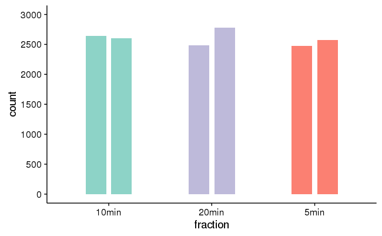

```r
###make the plot
id_plot = ggplot(pep_agg, aes(fraction, group=interaction(replicate,fraction))) +
  geom_bar(aes(fill=fraction), width=0.4, position = position_dodge(width=0.5)) +
  theme(legend.position="none") +
  scale_fill_manual(values=brewer.pal(6,"Set3")[c(1,3:4)]) +
  scale_y_continuous(limits = c(0,3000), breaks = seq(0,3000,500))
id_plot #call the plot
save_plot('/projects/ptx_analysis/chughes/projects-current/sp3-follow-up/binding-testing/Routput/ch_feb2018_SP3-binding-incubation-time_protein-barplot.pdf',id_plot)
```

Now look at the protein overlap.

```r
pep_agg$number.of.hits = 1 #add a protein counter
pep_agg$sample.set = paste(pep_agg$fraction,'_',pep_agg$replicate,sep="") #add a more specific sample description
protein_wide = spread(pep_agg[,c(1,6,5)], sample.set, number.of.hits) #convert to wide format
protein_wide[is.na(protein_wide)] = 0 #change the NA values during the wide conversion to zeros for the UpSet plot
```

Make an upset ploto of the data.

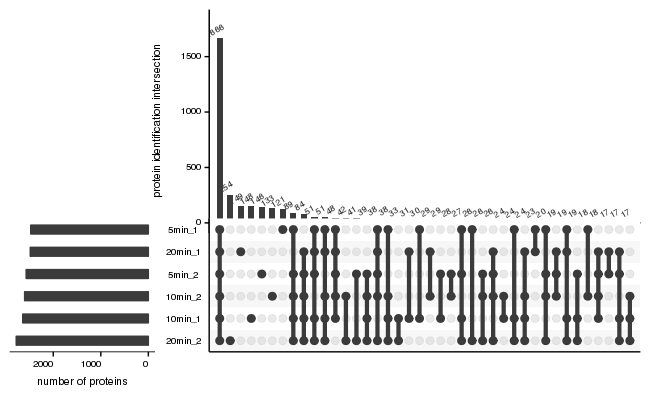

```r
#the pdf code is just for saving purposes, hash out for the notebook
#pdf('/projects/ptx_analysis/chughes/projects-current/sp3-follow-up/binding-testing/Routput/ch_feb2018_SP3-binding-incubation-time_protein-identification-overlap-all.pdf')
#upset(protein_wide, nsets = 8, number.angles = 30, point.size = 2.5, line.size = 1.5,
#    mainbar.y.label = "protein identification intersection", sets.x.label = "number of proteins", order.by = "freq", mb.ratio = c(0.55, 0.45))
#dev.off()
#now for the notebook plot
all_sets_upset = upset(protein_wide, nsets = 8, number.angles = 30, point.size = 2.5, line.size = 1.5,
    mainbar.y.label = "protein identification intersection", sets.x.label = "number of proteins", order.by = "freq", mb.ratio = c(0.55, 0.45))
```

```r
#this one is still kind of confusing even for proteins
```

```r
pro_fraction_agg <- setDT(psm_set)[, lapply(.SD,mean,na.rm=TRUE),by=.(accession,fraction),.SDcols=c('PrecursorMaxIntensity')] #collapse by fraction
setDF(pro_fraction_agg) # convert back to dataframe
pro_fraction_agg$number.of.hits = 1 #add a protein counter
protein_wide = spread(pro_fraction_agg[,c(1,2,4)], fraction, number.of.hits) #convert to wide format
protein_wide[is.na(protein_wide)] = 0 #change the NA values during the wide conversion to zeros for the UpSet plot
```

Make the plot of the data for a pdf.

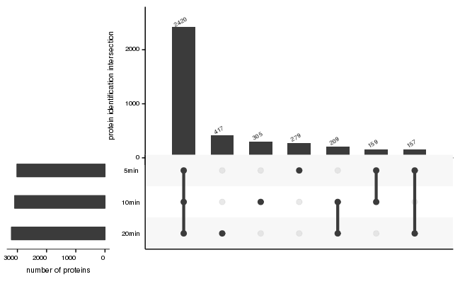

```r
#pdf('/projects/ptx_analysis/chughes/projects-current/sp3-follow-up/binding-testing/Routput/ch_feb2018_SP3-binding-incubation-time_protein-identification-overlap-fractions.pdf')
#upset(protein_wide, nsets = 4, number.angles = 30, point.size = 2.5, line.size = 1.5,
#    mainbar.y.label = "protein identification intersection", sets.x.label = "number of proteins", order.by = "freq", mb.ratio = c(0.55, 0.45))
#dev.off()
#now for the notebook plot
fractions_upset = upset(protein_wide, nsets = 4, number.angles = 30, point.size = 2.5, line.size = 1.5,
    mainbar.y.label = "protein identification intersection", sets.x.label = "number of proteins", order.by = "freq", mb.ratio = c(0.55, 0.45))
```

Would also be interested to know the overlap between replicates, although I don’t think a plot is necessary here.

```r
pro_agg <- setDT(psm_set)[, lapply(.SD,mean,na.rm=TRUE),by=.(accession,fraction,replicate),.SDcols=c('PrecursorMaxIntensity')] #collapse by accession, fraction, and replicate
setDF(pro_agg) # convert back to dataframe
pro_agg_replicates = subset(pro_agg, fraction == '20min') #subset by the set of interest...just change this to see the others
pro_agg_replicates$number.of.hits = 1 #add a protein counter
pro_agg_replicates$sample.set = paste(pro_agg_replicates$fraction,'_',pro_agg_replicates$replicate,sep="") #add a more specific sample description
protein_wide = spread(pro_agg_replicates[,c(1,6,5)], sample.set, number.of.hits) #convert to wide format
protein_wide[is.na(protein_wide)] = 0 #change the NA values during the wide conversion to zeros for the UpSet plot
```

Make the plot of the data for pdf.

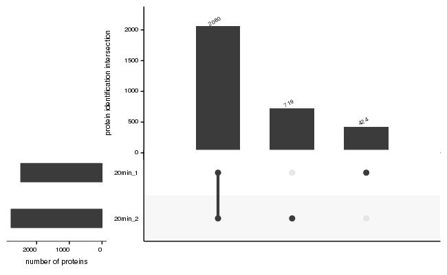

```r
#pdf('/projects/ptx_analysis/chughes/projects-current/sp3-follow-up/binding-testing/Routput/ch_feb2018_SP3-binding-incubation-time_20min_protein-identification-overlap.pdf')
#upset(protein_wide, nsets = 2, number.angles = 30, point.size = 2.5, line.size = 1.5,
#    mainbar.y.label = "protein identification intersection", sets.x.label = "number of proteins", order.by = "freq", mb.ratio = c(0.55, 0.45))
#dev.off()
#now for the notebook plot
replicates_upset = upset(protein_wide, nsets = 2, number.angles = 30, point.size = 2.5, line.size = 1.5,
    mainbar.y.label = "protein identification intersection", sets.x.label = "number of proteins", order.by = "freq", mb.ratio = c(0.55, 0.45))
```

End of the incubation time data.

## Mixing and rinsing methods data set

Now I will move on to the incubation type data (e.g. mixing, rinsing) and perform the same analysis. Locate the input files for identifications and quantification.

```r
id_files = list.files('/projects/ptx_analysis/chughes/projects-current/sp3-follow-up/binding-testing/reports-output', pattern='.*Binding.*Default_PSM_Report.txt',full.names=TRUE) #psm files
quant_files = list.files('/projects/ptx_analysis/chughes/projects-current/sp3-follow-up/binding-testing/quant-output', pattern='.*Binding.*MS2ParseData.txt',full.names=TRUE) #ms2 files
```

Read in the identification data into a single data frame object

```r
id_parsed = data.frame() #identification data storage object
#iterate over the identification files
for (i in 1:length(id_files)){
  psm_in = read.table(id_files[i],header=TRUE,sep='\t') #input file
  psm_f1 = psm_in %>%
    dplyr::select(Protein.s., Sequence, Spectrum.File, Spectrum.Title, m.z, Identification.Charge) %>% #select columns
    dplyr::mutate(Spectrum.Title, scan_num = sub(".*?spectrum (.*?)", "\\1", Spectrum.Title)) %>% #parse out the scan number
    dplyr::mutate(Identification.Charge, id_charge = gsub("[^0-9]", "", Identification.Charge)) %>% #parse out the charge
    dplyr::mutate(Spectrum.Title, fraction = sub(".*?100p_(.*?)_[0-9]_MGF\\.mgf", "\\1", Spectrum.File)) %>% #parse the fraction
    dplyr::mutate(Spectrum.Title, replicate = sub(".*?rinse-[a-zA-Z]+_(.*?)_MGF\\.mgf", "\\1", Spectrum.File)) %>% #parse the replicate
    dplyr::select(Protein.s., Sequence, scan_num, m.z, id_charge, fraction, replicate) %>% #select new columns
    dplyr::mutate(Protein.s., first_accession = sapply(strsplit(as.character(Protein.s.),"\\,"), `[`, 1)) #parse the accession
  #adjust the column names
  colnames(psm_f1) = c('accession_groups','sequence','ScanNumber','id_precursor_mz','id_charge','fraction','replicate','accession')
  psm_f2 = dplyr::filter(psm_f1, !grepl('CONT_', accession_groups)) #remove the contaminant proteins
  id_parsed = rbind(id_parsed,psm_f2) #group the data with the previously processed set
}
```

Now we can process the rawquant data for the intensity values.

```r
quant_parsed = data.frame()
#iterate over the rawquant files
for (i in 1:length(quant_files)){
  quant_in = read.table(quant_files[i],header=TRUE,sep='\t') #input file
  quant_in$fraction = sub(".*?100p_(.*?)_[0-9]_MS2ParseData\\.txt", "\\1", quant_files[i]) #parse out the fraction
  quant_in$replicate = sub(".*?rinse-[a-zA-Z]+_(.*?)_MS2ParseData\\.txt", "\\1", quant_files[i]) #parse out the replicate
  quant_parsed = rbind(quant_parsed, quant_in) #combine with the previous data
}
```

Now we can combine the two data sets together using a simple merge and save the data.

```r
id_quant = merge(id_parsed, quant_parsed, by=c('ScanNumber', 'fraction', 'replicate'))
saveRDS(id_quant, '/projects/ptx_analysis/chughes/projects-current/sp3-follow-up/binding-testing/Routput/ch_feb2018_SP3-binding-mixing-rinsing_id-quant-all.rds') #save the data
```

Now that I have the compiled data set, I want to plot how well the identified peptides track across the different processing types. I can do this using their intensities from rawquant.

```r
###first read in the data file I just prepared
psm_set = readRDS('/projects/ptx_analysis/chughes/projects-current/sp3-follow-up/binding-testing/Routput/ch_feb2018_SP3-binding-mixing-rinsing_id-quant-all.rds') #read processed data
```

Collapse redundant psm’s in the data.

```r
psm_agg <- setDT(psm_set)[, lapply(.SD,mean,na.rm=TRUE),by=.(sequence,fraction,replicate),.SDcols=c('PrecursorMaxIntensity')] #collapse by sequence and replicate
setDF(psm_agg) # convert back to dataframe
dim(psm_agg) #77057 rows are remaining
```

```
[1] 77057     4
```

I am only interested in peptides that were identified in all 8 samples for this specific plot

```r
peptide_set = names(which(table(psm_agg$sequence) == 8)) #extract the peptides found in all 8 samples, this keeps 3092 peptides
peptide_subset = psm_agg[psm_agg$sequence %in% peptide_set,] #filter the data matrix to only keep peptides found in all 8 samples
dim(peptide_subset) #this should be 3092 * 8 rows in length, and it is!
```

```
[1] 24736     4
```

Now plot the data.

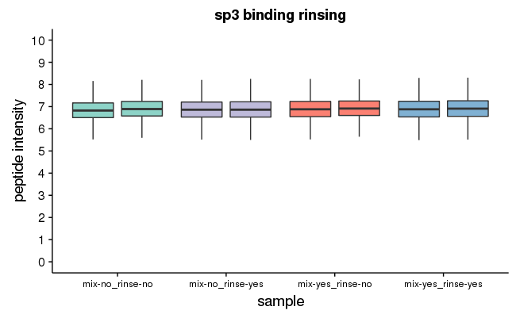

```r
binding_plot = ggplot(peptide_subset, aes(fraction, log10(PrecursorMaxIntensity),group=interaction(replicate,fraction))) +
    #geom_point(aes(fill=replicate),position=position_jitterdodge(dodge.width=0.9),colour='grey60',alpha=0.1) +
    geom_boxplot(aes(fill=fraction), position=position_dodge(width=0.9),outlier.colour=NA) +
    labs(x = "sample", y = 'peptide intensity', title = 'sp3 binding rinsing') +
    theme(axis.text.x = element_text(size = 9)) +
    scale_fill_manual(values=brewer.pal(6,"Set3")[c(1,3:5)]) +
    scale_y_continuous(limits = c(0,10), breaks = seq(0,10,1)) +
    #scale_y_continuous(limits=c(0,1.5e9)) +
    theme(legend.position="none")
binding_plot #call the plot
save_plot('/projects/ptx_analysis/chughes/projects-current/sp3-follow-up/binding-testing/Routput/ch_feb2018_SP3-binding-rinsing_peptide-boxplot.pdf',binding_plot)
```

```r
dim(peptide_subset) #24736 peptides present in this plot
```

```
[1] 24736     4
```

Again, this looks good…but it doesn’t tell me anything about recovery of identical peptides across the incubation times. For this we could use a correlation. Calculate and plot the correlation in intensities between a pair of replicate samples.

```r
peptide_wide = spread(peptide_subset, fraction, PrecursorMaxIntensity) #convert to wide format
cor(peptide_wide[,3:6],method = 'pearson')
```

```
                  mix-no_rinse-no mix-no_rinse-yes mix-yes_rinse-no mix-yes_rinse-yes
mix-no_rinse-no         1.0000000        0.9374846        0.9488203         0.9514509
mix-no_rinse-yes        0.9374846        1.0000000        0.9394673         0.9392611
mix-yes_rinse-no        0.9488203        0.9394673        1.0000000         0.9349239
mix-yes_rinse-yes       0.9514509        0.9392611        0.9349239         1.0000000
```

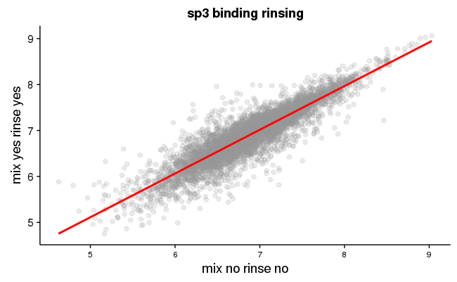

```r
#so the correlation is very nice here. Can state these values in the text, but make one plot as a display.
colnames(peptide_wide) = c('sequence','replicate','mix.no.rinse.no','mix.no.rinse.yes','mix.yes.rinse.no','mix.yes.rinse.yes')
binding_corplot = ggplot(peptide_wide, aes(log10(mix.no.rinse.no), log10(mix.yes.rinse.yes))) +
    geom_point(colour='grey60',alpha=0.2,size=2) +
    geom_smooth(method='lm',color='red') +
    labs(x = "mix no rinse no", y = 'mix yes rinse yes', title = 'sp3 binding rinsing') +
    theme(axis.text.x = element_text(size = 9)) +
    #scale_y_continuous(limits=c(0,1.5e9)) +
    theme(legend.position="none")
binding_corplot #call the plot
save_plot('/projects/ptx_analysis/chughes/projects-current/sp3-follow-up/binding-testing/Routput/ch_feb2018_SP3-binding-rinsing-mixYES-rinseYES_peptide-scatter.pdf',binding_corplot)
```

```r
dim(peptide_wide) #24736 peptides present in this plot
```

```
[1] 6184    6
```

I am also interested to look at some identification metrics for these data.

```r
###first read in the data file I just prepared
psm_set = readRDS('/projects/ptx_analysis/chughes/projects-current/sp3-follow-up/binding-testing/Routput/ch_feb2018_SP3-binding-mixing-rinsing_id-quant-all.rds') #read processed data
```

Collapse redundant psm’s in the data.

```r
psm_agg <- setDT(psm_set)[, lapply(.SD,mean,na.rm=TRUE),by=.(sequence,fraction,replicate),.SDcols=c('PrecursorMaxIntensity')] #collapse by sequence, fraction, and replicate
setDF(psm_agg) # convert back to dataframe
dim(psm_agg) #77057 rows are remaining
```

```
[1] 77057     4
```

```r
###what do the general peptide identification metrics look like
table(psm_agg$fraction, psm_agg$replicate)
```

```
                       1    2
  mix-no_rinse-no   9098 9789
  mix-no_rinse-yes  9958 9909
  mix-yes_rinse-no  8877 9658
  mix-yes_rinse-yes 9957 9811
```

Make a plot of these data.

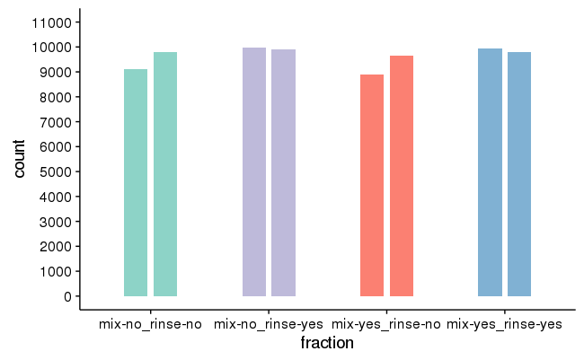

```r
###make the plot
id_plot = ggplot(psm_agg, aes(fraction, group=interaction(replicate,fraction))) +
  geom_bar(aes(fill=fraction), width=0.4, position = position_dodge(width=0.5)) +
  theme(legend.position="none") +
  scale_fill_manual(values=brewer.pal(6,"Set3")[c(1,3:5)]) +
  scale_y_continuous(limits = c(0,11000), breaks = seq(0,11000,1000))
id_plot #call the plot
save_plot('/projects/ptx_analysis/chughes/projects-current/sp3-follow-up/binding-testing/Routput/ch_feb2018_SP3-binding-rinsing_peptide-barplot.pdf',id_plot)
```

Now look at the peptide overlap.

```r
psm_agg$number.of.hits = 1 #add a peptide counter
psm_agg$sample.set = paste(psm_agg$fraction,'_',psm_agg$replicate,sep="") #add a more specific sample description
peptide_wide = spread(psm_agg[,c(1,6,5)], sample.set, number.of.hits) #convert to wide format
peptide_wide[is.na(peptide_wide)] = 0 #change the NA values during the wide conversion to zeros for the UpSet plot
```

Make an upset ploto of the data.

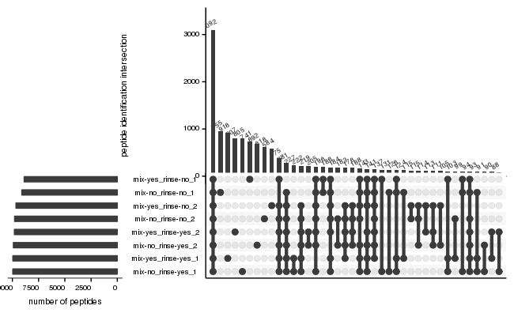

```r
#pdf('/projects/ptx_analysis/chughes/projects-current/sp3-follow-up/binding-testing/Routput/ch_feb2018_SP3-binding-rinsing_identification-overlap-all.pdf')
#upset(peptide_wide, nsets = 8, number.angles = 30, point.size = 2.5, line.size = 1.5,
#    mainbar.y.label = "peptide identification intersection", sets.x.label = "number of peptides", order.by = "freq", mb.ratio = c(0.55, 0.45))
#dev.off()
all_sets_upset = upset(peptide_wide, nsets = 8, number.angles = 30, point.size = 2.5, line.size = 1.5,
    mainbar.y.label = "peptide identification intersection", sets.x.label = "number of peptides", order.by = "freq", mb.ratio = c(0.55, 0.45))
```

This plot is kind of confusing. Might be a better idea to just do the 4 sets with combined replicates, then replicates separately.

```r
psm_fraction_agg <- setDT(psm_set)[, lapply(.SD,mean,na.rm=TRUE),by=.(sequence,fraction),.SDcols=c('PrecursorMaxIntensity')] #collapse by fraction
setDF(psm_fraction_agg) # convert back to dataframe
psm_fraction_agg$number.of.hits = 1 #add a peptide counter
peptide_wide = spread(psm_fraction_agg[,c(1,2,4)], fraction, number.of.hits) #convert to wide format
peptide_wide[is.na(peptide_wide)] = 0 #change the NA values during the wide conversion to zeros for the UpSet plot
```

Make the plot of the data.

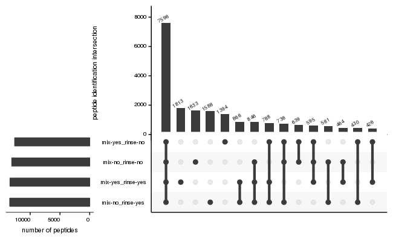

```r
#pdf('/projects/ptx_analysis/chughes/projects-current/sp3-follow-up/binding-testing/Routput/ch_feb2018_SP3-binding-rinsing_identification-overlap-fractions.pdf')
#upset(peptide_wide, nsets = 4, number.angles = 30, point.size = 2.5, line.size = 1.5,
#    mainbar.y.label = "peptide identification intersection", sets.x.label = "number of peptides", order.by = "freq", mb.ratio = c(0.55, 0.45))
#dev.off()
fractions_upset = upset(peptide_wide, nsets = 4, number.angles = 30, point.size = 2.5, line.size = 1.5,
    mainbar.y.label = "peptide identification intersection", sets.x.label = "number of peptides", order.by = "freq", mb.ratio = c(0.55, 0.45))
```

Would also be interested to know the overlap between replicates, although I don’t think a plot is necessary here.

```r
psm_agg <- setDT(psm_set)[, lapply(.SD,mean,na.rm=TRUE),by=.(sequence,fraction,replicate),.SDcols=c('PrecursorMaxIntensity')] #collapse by sequence, fraction, and replicate
setDF(psm_agg) # convert back to dataframe
psm_agg_replicates = subset(psm_agg, fraction == 'mix-no_rinse-no') #subset by the set of interest...just change this to see the others
psm_agg_replicates$number.of.hits = 1 #add a peptide counter
psm_agg_replicates$sample.set = paste(psm_agg_replicates$fraction,'_',psm_agg_replicates$replicate,sep="") #add a more specific sample description
peptide_wide = spread(psm_agg_replicates[,c(1,6,5)], sample.set, number.of.hits) #convert to wide format
peptide_wide[is.na(peptide_wide)] = 0 #change the NA values during the wide conversion to zeros for the UpSet plot
```

Make the plot of the data.

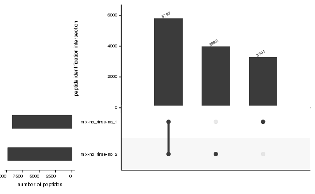

```r
#pdf('/projects/ptx_analysis/chughes/projects-current/sp3-follow-up/binding-testing/Routput/ch_feb2018_SP3-binding-rinsing_mix-no-rinse-no_identification-overlap.pdf')
#upset(peptide_wide, nsets = 2, number.angles = 30, point.size = 2.5, line.size = 1.5,
#    mainbar.y.label = "peptide identification intersection", sets.x.label = "number of peptides", order.by = "freq", mb.ratio = c(0.55, 0.45))
#dev.off()
replicates_upset = upset(peptide_wide, nsets = 2, number.angles = 30, point.size = 2.5, line.size = 1.5,
    mainbar.y.label = "peptide identification intersection", sets.x.label = "number of peptides", order.by = "freq", mb.ratio = c(0.55, 0.45))
```

So the overlap here is around 65% based on peptide identifications. I am also interested in seeing the same data, but for proteins

```r
###first read in the data file I just prepared
psm_set = readRDS('/projects/ptx_analysis/chughes/projects-current/sp3-follow-up/binding-testing/Routput/ch_feb2018_SP3-binding-mixing-rinsing_id-quant-all.rds') #read processed data
```

Collapse redundant peptides in the data.

```r
pep_agg <- setDT(psm_set)[, lapply(.SD,mean,na.rm=TRUE),by=.(accession,fraction,replicate),.SDcols=c('PrecursorMaxIntensity')] #collapse by accession, fraction, and replicate
setDF(pep_agg) # convert back to dataframe
dim(pep_agg) #20879 rows are remaining
```

```
[1] 20879     4
```

```r
###what do the general protein identification metrics look like
table(pep_agg$fraction, pep_agg$replicate)
```

```
                       1    2
  mix-no_rinse-no   2497 2589
  mix-no_rinse-yes  2700 2695
  mix-yes_rinse-no  2476 2594
  mix-yes_rinse-yes 2694 2634
```

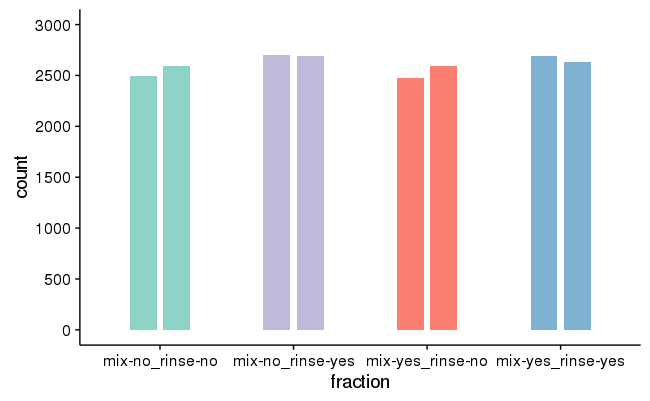

```r
###make the plot
id_plot = ggplot(pep_agg, aes(fraction, group=interaction(replicate,fraction))) +
  geom_bar(aes(fill=fraction), width=0.4, position = position_dodge(width=0.5)) +
  theme(legend.position="none") +
  scale_fill_manual(values=brewer.pal(6,"Set3")[c(1,3:5)]) +
  scale_y_continuous(limits = c(0,3000), breaks = seq(0,3000,500))
id_plot #call the plot
save_plot('/projects/ptx_analysis/chughes/projects-current/sp3-follow-up/binding-testing/Routput/ch_feb2018_SP3-binding-rinsing_protein-barplot.pdf',id_plot)
```

Now look at the protein overlap.

```r
pep_agg$number.of.hits = 1 #add a protein counter
pep_agg$sample.set = paste(pep_agg$fraction,'_',pep_agg$replicate,sep="") #add a more specific sample description
protein_wide = spread(pep_agg[,c(1,6,5)], sample.set, number.of.hits) #convert to wide format
protein_wide[is.na(protein_wide)] = 0 #change the NA values during the wide conversion to zeros for the UpSet plot
```

Make an upset ploto of the data.

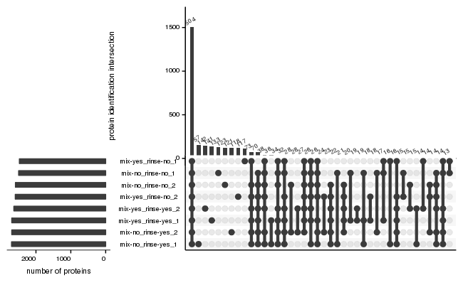

```r
#the pdf code is just for saving purposes, hash out for the notebook
#pdf('/projects/ptx_analysis/chughes/projects-current/sp3-follow-up/binding-testing/Routput/ch_feb2018_SP3-binding-rinsing_protein-identification-overlap-all.pdf')
#upset(protein_wide, nsets = 8, number.angles = 30, point.size = 2.5, line.size = 1.5,
#    mainbar.y.label = "protein identification intersection", sets.x.label = "number of proteins", order.by = "freq", mb.ratio = c(0.55, 0.45))
#dev.off()
#now for the notebook plot
all_sets_upset = upset(protein_wide, nsets = 8, number.angles = 30, point.size = 2.5, line.size = 1.5,
    mainbar.y.label = "protein identification intersection", sets.x.label = "number of proteins", order.by = "freq", mb.ratio = c(0.55, 0.45))
```

```r
#this one is still kind of confusing even for proteins
```

Might be a better idea to just do the 4 sets with combined replicates, then replicates separately.

```r
pro_fraction_agg <- setDT(psm_set)[, lapply(.SD,mean,na.rm=TRUE),by=.(accession,fraction),.SDcols=c('PrecursorMaxIntensity')] #collapse by fraction
setDF(pro_fraction_agg) # convert back to dataframe
pro_fraction_agg$number.of.hits = 1 #add a protein counter
protein_wide = spread(pro_fraction_agg[,c(1,2,4)], fraction, number.of.hits) #convert to wide format
protein_wide[is.na(protein_wide)] = 0 #change the NA values during the wide conversion to zeros for the UpSet plot
```

Make the plot of the data for a pdf.

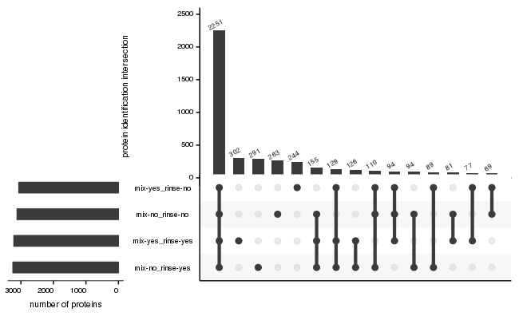

```r
#pdf('/projects/ptx_analysis/chughes/projects-current/sp3-follow-up/binding-testing/Routput/ch_feb2018_SP3-binding-rinsing_protein-identification-overlap-fractions.pdf')
#upset(protein_wide, nsets = 4, number.angles = 30, point.size = 2.5, line.size = 1.5,
#    mainbar.y.label = "protein identification intersection", sets.x.label = "number of proteins", order.by = "freq", mb.ratio = c(0.55, 0.45))
#dev.off()
#now for the notebook plot
fractions_upset = upset(protein_wide, nsets = 4, number.angles = 30, point.size = 2.5, line.size = 1.5,
    mainbar.y.label = "protein identification intersection", sets.x.label = "number of proteins", order.by = "freq", mb.ratio = c(0.55, 0.45))
```

Would also be interested to know the overlap between replicates, although I don’t think a plot is necessary here.

```r
pro_agg <- setDT(psm_set)[, lapply(.SD,mean,na.rm=TRUE),by=.(accession,fraction,replicate),.SDcols=c('PrecursorMaxIntensity')] #collapse by accession, fraction, and replicate
setDF(pro_agg) # convert back to dataframe
pro_agg_replicates = subset(pro_agg, fraction == 'mix-no_rinse-yes') #subset by the set of interest...just change this to see the others
pro_agg_replicates$number.of.hits = 1 #add a protein counter
pro_agg_replicates$sample.set = paste(pro_agg_replicates$fraction,'_',pro_agg_replicates$replicate,sep="") #add a more specific sample description
protein_wide = spread(pro_agg_replicates[,c(1,6,5)], sample.set, number.of.hits) #convert to wide format
protein_wide[is.na(protein_wide)] = 0 #change the NA values during the wide conversion to zeros for the UpSet plot
```

Make the plot of the data for pdf.

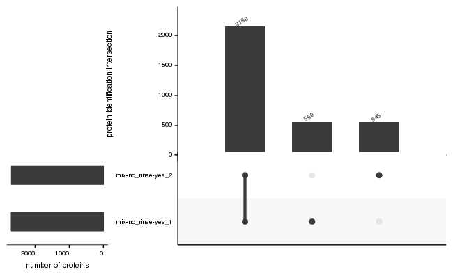

```r
#pdf('/projects/ptx_analysis/chughes/projects-current/sp3-follow-up/binding-testing/Routput/ch_feb2018_SP3-binding-rinsing_mix-no-rinse-yes_protein-identification-overlap.pdf')
#upset(protein_wide, nsets = 2, number.angles = 30, point.size = 2.5, line.size = 1.5,
#    mainbar.y.label = "protein identification intersection", sets.x.label = "number of proteins", order.by = "freq", mb.ratio = c(0.55, 0.45))
#dev.off()
#now for the notebook plot
replicates_upset = upset(protein_wide, nsets = 2, number.angles = 30, point.size = 2.5, line.size = 1.5,
    mainbar.y.label = "protein identification intersection", sets.x.label = "number of proteins", order.by = "freq", mb.ratio = c(0.55, 0.45))
```

Done.